# **My first program in python**

```python
print("hello")
```

```
hello
```

# **how to Comments in python**

```python
print("hello")
#this is comment
```

```
hello
```

```python
'''this is multi line
comment'''
```

# **Variables:**

A variable is like a container that stores values that you can access or change.

```python
my_variable=3
print(my_variable)
```

```
3
```

Declare more than one variable in single line.

```python
a,b,c=10,20,30
print(a)
```

```
10
```

```python
a=10
b=20
# print(a)
# print(b)
a,b=b,a
print(a)
print(b)
```

```
20
10
```

To increment/decriment the value of the variable

```python
a=20
a+=10
print(a)
```

```
30
```

# **Data Types:**

# **Numeric Data Types:**

1. Integer (int) Integers are whole numbers without decimal point. They can be positive or negative as long as they don’t contain a decimal point that would make a number a floating number, a distinct numeric type. Integers have unlimited size in Python 3.

Examples: 793, -254, 4

```python
a=20
print(type(a))
```

```
<class 'int'>
```

2. Floating-point numbers: Also known as floats, floating-point numbers signify real numbers. Floats are written with a decimal point that segregates the integer from the fractional numbers.

```python
a=0.33
print(type(a))
```

```
<class 'float'>
```

3. Complex numbers: Complex numbers are pairs of real and imaginary numbers. They take the form ‘a + bJ’ where ‘a’ is a float and the real part of the complex number. On the other side is bJ where ‘b’ is a float and J or its lowercase indicates the square root of an imaginary number, -1. This makes ‘b’ the imaginary part of the complex number.

```python
a=2+7J
print(type(a))
```

```
<class 'complex'>
```

```python
a=complex(2,-4)
print(a)
```

```
(2-4j)
```

Strings: A string is a sequence of characters that may be a combination of letters,numbers, and special symbols. To define a string in Python, you can enclose the string in matching single or double quotes:

```python
a='hello'
print(type(a))
```

```
<class 'str'>
```

# **Conversion of Type (TYPE CASTING):**

# **1. String into integer**

```python
a="57"
a=int(a)
print(type(a))
```

```
<class 'int'>
```

# **2. Float into integer**

```python
a=57.2
a=int(a)
print(a)
```

```
57
```

# **3. Integer into string**

```python
a=45
a=str(a)
print(a)
```

```
45
```

# **The input() Function**

```python
a=int(input())
b=int(input())
print(a+b)
```

```
20
10
30
```

# **The print() Function**

```python
print("hello")
print()
print('world')
```

```
hello

world
```

# **Print in same line :**

```python
print("hello",end='')
print()
```

[output not shown]

# **Python Operators:**

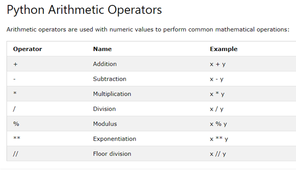

```python
a=9
b=2
print(a+b)
print(a-b)
print(a*b)
print(a/b)
print(a%b)
print(a**b)
print(a//b)
```

```
11
7
18
4.5
1
81
4
```

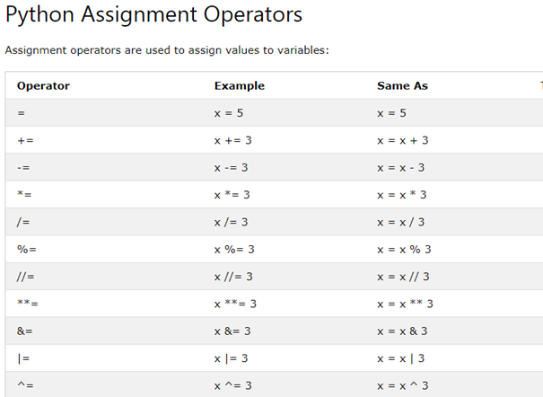

```python
x=5
x+=3
print(x)
```

[output not shown]

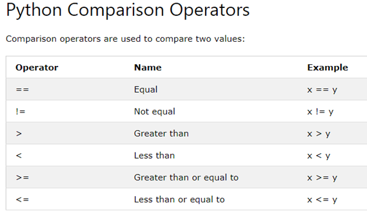

```python
x=9
y=2
print(x==y)
print(x!=y)
print(x>y)
print(x<y)
print(x>=y)
print(x<=y)
```

```
False
True
True
False
True
False
```

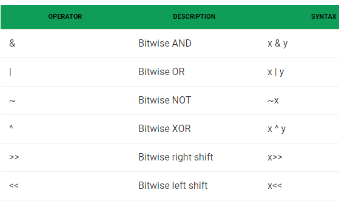

# **Bitwise and**

```python
a = 10            # 1010 (Binary)
b = 4             # 0100 (Binary)

# a & b = 1010
#          &
#         0100
#       = 0000
#       = 0 (Decimal)


print(a&b)
```

```
0
```

# **Bitwise or**

```python
a = 10             # 1010 (Binary)
b = 4              # 0100 (Binary)

# a & b = 1010
#          |
#         0100
#       = 1110
#       = 14 (Decimal)


print(a|b)
```

```
14
```

# **Bitwise not**

```python
a = 10              # 1010 (Binary)
# ~a = ~1010 = -(1010+1)= -1011 (Binary value of -11)
print(~a)
```

```
-11
```

```python
a = -10              # 0110 (Binary)
# ~a = ~0110 = 1001 (Binary value of 9)
print(~a)
```

```
9
```

# **Bitwise xor**

```python
a = 10          # 1010 (Binary)
b = 4           # 0100 (Binary

# a^b =   1010
#          ^
#         0100
#       = 1110
#       = 14 (Decimal)

print(a^b)
```

```
14
```

# **Bitwise Right Shift**

```python
# Example 1:
a = 10              # 0000 1010 (Binary)
print(a >> 1 )      # 0000 0101 = 5

# Example 2:
a = -10             # 1111 0110 (Binary)
print(a >> 1 )      # 0111 1011 = -5
```

```
5
-5
```

# **Bitwise Left Shift**

```python
# Example 1:
a = 5                # 0000 0101 (Binary)
print(a << 1)        # 0000 1010 = 10
print(a << 2)        # 0001 0100 = 20

# Example 2:
b = -10             # 1111 0110 (Binary)
print(b << 1)       # 1110 1100 = -20
print(b << 2)       # 1101 1000 = -40
```

```
10
20
-20
-40
```

# **Conditional Statements**

# **If else**

**syntax:**

if condition:

```
 block1_statement
```

else:

```
block3_statement
```

```python
a=4
b=5
if a>b:
    print(a)
else:
    print(b)
```

[output not shown]

# **If elif else**

**syntax:**

if condition1:

```
 block1_statement
```

elif condition2:

```
 block2_statament
```

else:

```
block3_statement
```

```python
a=8
b=7
c=6
if a>b and a>c:
    print(a)
elif b>a and b>c:
    print(b)
else:
    print(c)
```

[output not shown]

# **Bin function:**

It is used to find out binary value corrospond to decimal value.

```python
bin(10)
```

```
'0b1010'
```

# **int function:**

It is used to find out decimal value corrospond to binary value.

```python
int("1010",2)
```

```
10
```

# **hex function:**

It is used to find out hexadecimal value corrospond to decimal value.

```python
hex(20)
```

```
'0x14'
```

```python
int('0x14',16)
```

```
20
```

# **oct function:**

It is used to find out octal value corrospond to decimal value.

```python
oct(20)
```

```
'0o24'
```

```python
int('0o24',8)
```

```
20
```